# ANLY 512 Problem Set1

Xiaowei Wan

9/10/2017

# Questions

Find the mtcars data in R. This is the dataset that you will use to create your graphics. Use the dataset to draw graphics.

```r
data("mtcars")
summary(mtcars)
```

```
##       mpg             cyl             disp             hp
##  Min.   :10.40   Min.   :4.000   Min.   : 71.1   Min.   : 52.0
##  1st Qu.:15.43   1st Qu.:4.000   1st Qu.:120.8   1st Qu.: 96.5
##  Median :19.20   Median :6.000   Median :196.3   Median :123.0
##  Mean   :20.09   Mean   :6.188   Mean   :230.7   Mean   :146.7
##  3rd Qu.:22.80   3rd Qu.:8.000   3rd Qu.:326.0   3rd Qu.:180.0
##  Max.   :33.90   Max.   :8.000   Max.   :472.0   Max.   :335.0
##       drat             wt             qsec             vs
##  Min.   :2.760   Min.   :1.513   Min.   :14.50   Min.   :0.0000
##  1st Qu.:3.080   1st Qu.:2.581   1st Qu.:16.89   1st Qu.:0.0000
##  Median :3.695   Median :3.325   Median :17.71   Median :0.0000
##  Mean   :3.597   Mean   :3.217   Mean   :17.85   Mean   :0.4375
##  3rd Qu.:3.920   3rd Qu.:3.610   3rd Qu.:18.90   3rd Qu.:1.0000
##  Max.   :4.930   Max.   :5.424   Max.   :22.90   Max.   :1.0000
##        am              gear            carb
##  Min.   :0.0000   Min.   :3.000   Min.   :1.000
##  1st Qu.:0.0000   1st Qu.:3.000   1st Qu.:2.000
##  Median :0.0000   Median :4.000   Median :2.000
##  Mean   :0.4062   Mean   :3.688   Mean   :2.812
##  3rd Qu.:1.0000   3rd Qu.:4.000   3rd Qu.:4.000
##  Max.   :1.0000   Max.   :5.000   Max.   :8.000
```

```r
# import ggplot2 library
library(ggplot2)
```

- Create a pie chart showing the proportion of cars from the mtcars data set that have different carb values.

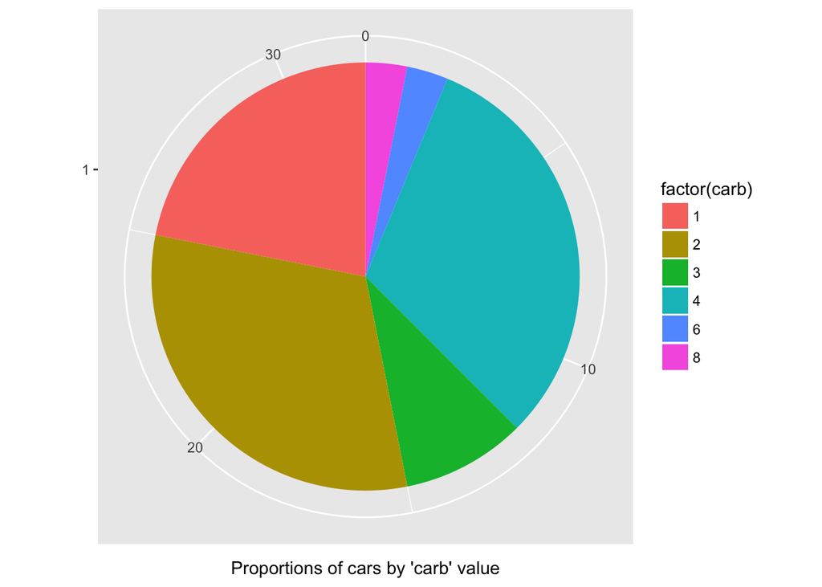

```r
# proportions of cars by 'carb' value
ggplot(data = mtcars, aes(x = factor(1), fill = factor(carb))) +
      ylab("Proportions of cars by 'carb' value") +
      xlab("") +
      geom_bar(width = 1) +
      coord_polar(theta = "y")
```

Observed from pie chart, it shows that cars with two and four carburetors have the highest proportion of 31.25%. Cars with one carburetor has proportion of 21.88%, cars with three carburetors has proportion of 9.37% and cars with six and eight carburetors have the smallest proportion of 3.12%.

- Create a bar graph, that shows the number of each gear type in mtcars.

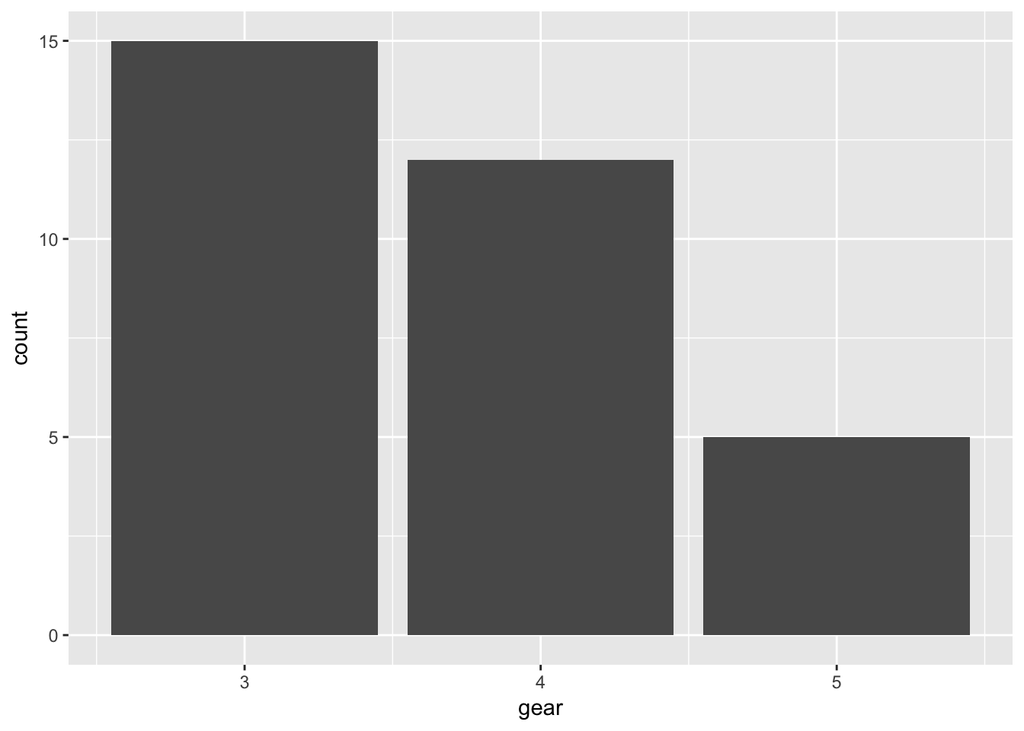

```r
# show the gear type in mtcars
ggplot(data = mtcars, aes(x = gear)) + geom_bar(stat = "count")
```

Observed from bar chart by gear type, it shows that 15 cars have three gears, 12 cars have four gears and 5 cars have five gears.

- Next show a stacked bar graph of the number of each gear type and how they are further divided out by cyl.

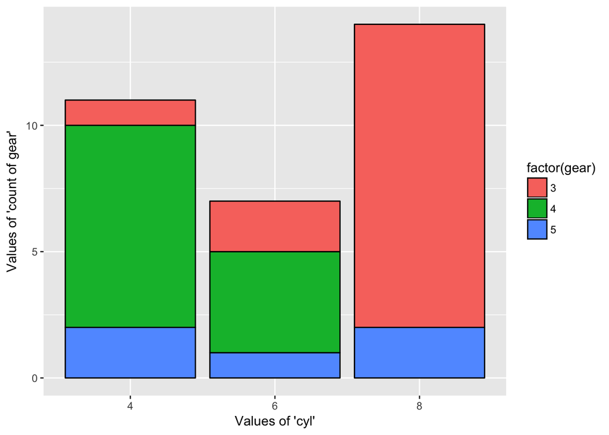

```r
# show a stacked bar graph of the number of each gear type and divided out by cyl.
ggplot(mtcars, aes(x = factor(cyl), fill = factor(gear))) +
    xlab("Values of 'cyl'") +
    ylab("Values of 'count of gear'") +
    geom_bar(color = "black")
```

Observed from the stached bar graph, it shows that for four cylinder cars, only 1 car has three gears, 8 cars have four gears and 2 cars have five gears; For six cyliner cars, 2 cars have three gears, 4 cars have four gears and 1 car has five years; For 8 cylinder cars, 12 cars have three gears, 2 cars have five gears and no car has four gears.

- Draw a scatter plot showing the relationship between wt and mpg.

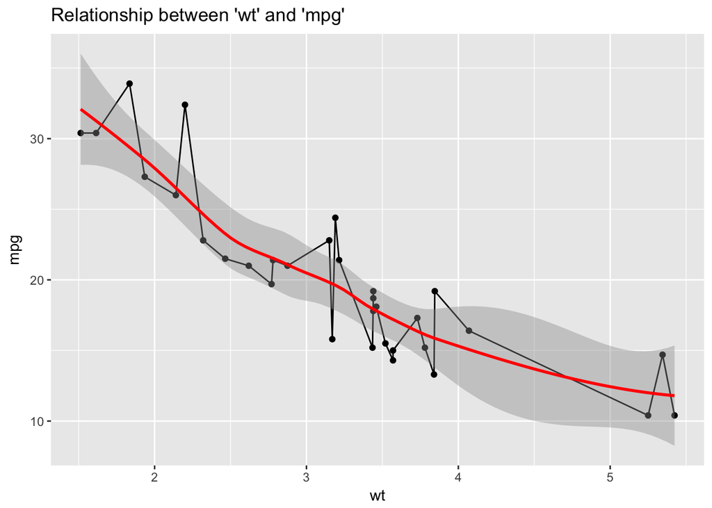

```r
ggplot(mtcars, aes(x = wt, y = mpg)) +
    xlab("wt") +
    ylab("mpg") +
    geom_point() +
    geom_line() +
    ggtitle("Relationship between 'wt' and 'mpg'") +
    stat_smooth(method = "loess", formula = y ~ x, size = 1, col = "red")
```

Observed from scatter plot, it shows that it is a negative relationship between weight and mpg. As weight increase, miles per gallon decreases.

- Design a visualization of your choice using the data and write a brief summary about why you chose that visualization.

I chose ggplot for the data visualization for this problem set, because the graphics are widely used to draw graphs and it is easy to use to plot a different graph, it has higher aesthetic values.